# The squared error has friends, too!

2019-03-16

## Who am I?

## Quiz

## True or False:

- The least squares estimator is derived by maximizing the likelihood.

## True or False:

- The least squares estimator is derived by maximizing the likelihood.
- If errors are not Gaussian, we can't use least squares to estimate our regression coefficients.

## True or False:

- The least squares estimator is derived by maximizing the likelihood.
- If errors are not Gaussian, we can't use least squares to estimate our regression coefficients.

**Answers**: Both FALSE!

## Question:

When we fit a regression model (linear, kNN, random forest, etc.), what is the interpretation of the resulting model function / regression curve?

## Question:

When we fit a regression model (linear, kNN, random forest, etc.), what is the interpretation of the resulting model function / regression curve?

**Answer**: The mean of Y given X.

## Concept #1

We minimize the SSE in regression because it's a proper scoring rule for the mean.

On the board, lets:

1. Write ybar as a minimization problem.
2. Extend to regression

## Concept #2

When doing regression, we ought to consider quantiles, too!

Consider Y = monthly expenditure (in $). Interpretation of quantities:

- median:
- low-quantile:
- high-quantile:
- mean:

Consider Y = monthly expenditure (in $). Interpretation of quantities:

- median: There's a 50-50 chance that you'll have to pay more than this.
- low-quantile:
- high-quantile:
- mean:

Consider Y = monthly expenditure (in $). Interpretation of quantities:

- median: There's a 50-50 chance that you'll have to pay more than this.
- low-quantile: You'll "at least" have to pay this much.
- high-quantile:
- mean:

Consider Y = monthly expenditure (in $). Interpretation of quantities:

- median: There's a 50-50 chance that you'll have to pay more than this.
- low-quantile: You'll "at least" have to pay this much.
- high-quantile: You'll "at most" have to pay this much.
- mean:

Consider Y = monthly expenditure (in $). Interpretation of quantities:

- median: There's a 50-50 chance that you'll have to pay more than this.
- low-quantile: You'll "at least" have to pay this much.
- high-quantile: You'll "at most" have to pay this much.
- mean: Multiply by `m` to estimate total $ after `m` months.

## Concept #3

Each quantile has its own proper scoring rule that we can use instead of the squared error.

On the board:

1. Write median as an optimization problem
2. Extend to generic quantile
3. Extend to regression

The "check function":

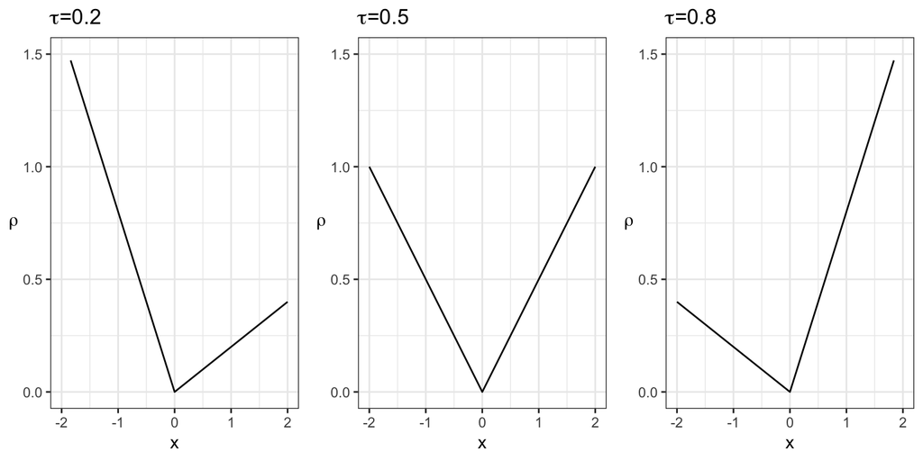

## Concept #4

Make a distributional assumption to reduce estimation uncertainty.

## Univariate Estimation

If you have a univariate sample \(Y_1, \ldots, Y_n\):

| Distributional Assumption? | Estimation Method |
| --- | --- |
| No |  |
| Yes |  |

## Univariate Estimation

If you have a univariate sample \(Y_1, \ldots, Y_n\):

| Distributional Assumption? | Estimation Method |
| --- | --- |
| No | "sample versions": ybar, s^2, `quantile()`, … |
| Yes | MLE |

## Regression setting

If you have a univariate sample \(Y_1, \ldots, Y_n\) AND predictors:

| Distributional Assumption? | Estimation Method |
| --- | --- |
| No |  |
| Yes |  |

## Regression setting

If you have a univariate sample \(Y_1, \ldots, Y_n\) AND predictors:

| Distributional Assumption? | Estimation Method |
| --- | --- |
| No | Optimize scoring rule for desired quantity. |
| Yes | MLE |

## Return of the Quiz

## Return of the Quiz

Can we see why these are false?

- The least squares estimator is derived by maximizing the likelihood.
- If errors are not Gaussian, we can't use least squares to estimate our regression coefficients.

## Time left?

## Time left?

Give two ways to estimate the conditional variance.

**Hint**: Think about the definition of variance.

Talk to your neighbour for 1 minute

## Resources

This talk was inspired by the activity generated by [my blog post "The missing question in supervised learning"](https://vincenzocoia.github.io/20180218-mean/).

For proper scoring rules, see [Gneiting, T., and Raftery, A.E. (2007) "Strictly Proper Scoring Rules, Prediction, and Estimation". Journal of the American Statistical Association, 102:477](https://www.stat.washington.edu/raftery/Research/PDF/Gneiting2007jasa.pdf)